# Report of Analysis and Visualization

```python
# Import relevant libraries
import pandas as pd
import matplotlib.pyplot as plt
%matplotlib inline
import seaborn as sns
```

# Introduction

Imagine for a moment that you have to rate these adorable dogs, what would you probably score them out of 10 marks?

[figure not shown]

Well, we thought so too. Definitely they have to score way higher than 10 marks because they are good dogs, Brent.

Now, suppose you were asked which dog breed is most loved in the USA? Well, your guess definitely is among one of these:

- Golden Retriever
- Labrador Retriever
- Pembroke
- Chihuahua
- Pug
- Chow
- Toy_puddle
- German Shepherd

No doubt, these are the breed of dogs most loved in the USA, or so I thought.

Now, suppose we ask Twitter to help us out. Twitter points us to a handle named @dog_rates. The screen name of the handle is WeRateDogs. Dog owners send pictures of their dogs to this handle and the dogs are rated. We gat some data for a few years on the breed of dogs that has been sent for rating. What do we find?

Well check out the top 7 dog breeds according to we rate dogs (earlier than 2017 tho :)):

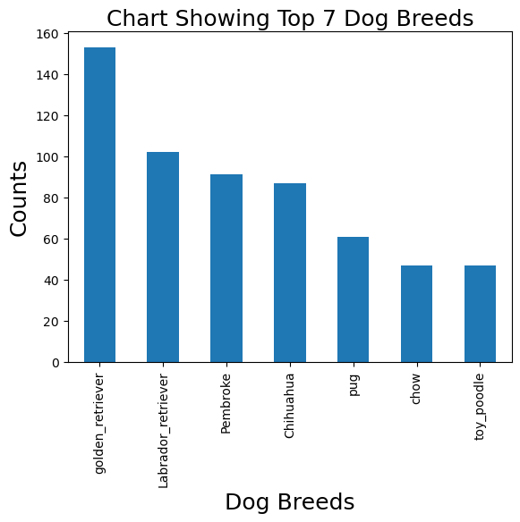

```python
twitter_archive_master = pd.read_csv('twitter_archive_master.csv')
breeds = list(twitter_archive_master['dog_breed'].value_counts().index[:7])
twitter_archive_master = twitter_archive_master.loc[twitter_archive_master['dog_breed'].isin(breeds)]

twitter_archive_master.dog_breed.value_counts().plot(kind='bar');
plt.title('Chart Showing Top 7 Dog Breeds', fontsize=18, pad=5)
plt.xlabel('Dog Breeds', fontsize=18)
plt.ylabel('Counts', fontsize=18)
plt.show()
```

[figure not shown]

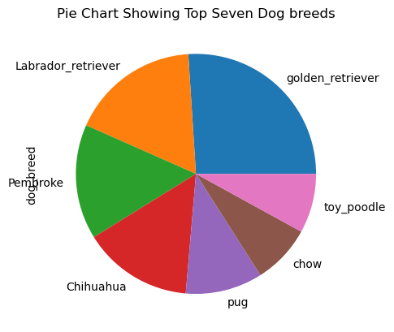

```python
twitter_archive_master.dog_breed.value_counts().plot(kind='pie');
plt.title('Pie Chart Showing Top Seven Dog breeds');
```

Alright. We got one more question for you:

If a random person is swipping through some random dog tweets on WeRateDogs, which dog breed is most likely to get more likes?

Well, the chart below gives us the numbers:

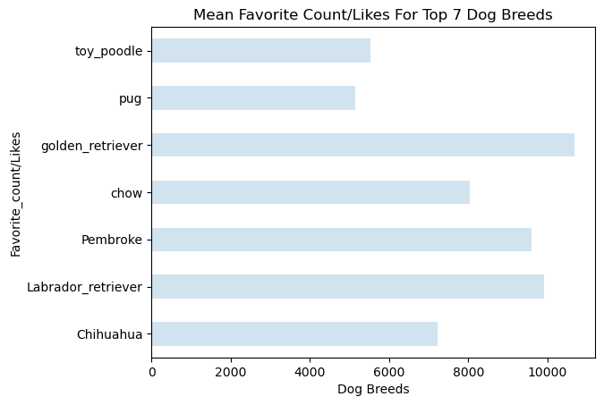

```python
#Let's plot the mean favorite count on a chart
mean_favorite_count = twitter_archive_master.groupby('dog_breed')['favorite_count'].mean()
mean_favorite_count.plot(kind='barh', title='Mean Favorite Count/Likes For Top 7 Dog Breeds', alpha=.2)
plt.xlabel('Dog Breeds')
plt.ylabel('Favorite_count/Likes')
plt.show();
```

Now, to our final question for you:

Which dog breed is most likely to score higher given a few picture of dog breeds in the USA?

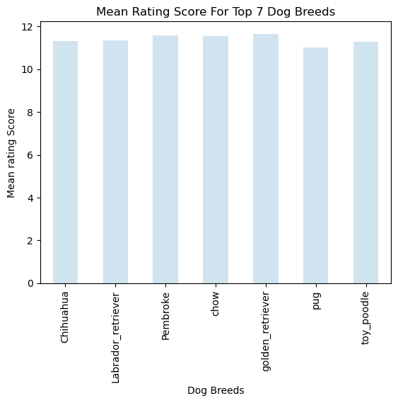

```python
mean_score_rating = twitter_archive_master.groupby(['dog_breed'])['rating_numerator'].mean()
mean_score_rating.plot(kind='bar', title='Mean Rating Score For Top 7 Dog Breeds', alpha=.2)
plt.xlabel('Dog Breeds')
plt.ylabel('Mean rating Score')
plt.show();
```

Let's see if this is actually true.

Well, it is true. A visit to [this website](https://worlddogfinder.com/blog/dog-breeds/most-popular-dog-breeds) confirms that trend.

It turns out that the list above was complied in 2022. Maybe we should check out a website that has listing earlier than 2022, say 2021.

Well, the story is the same. [check this out also](https://www.mentalfloss.com/article/643867/most-popular-dog-breeds-america)